# PageRank analysis

In this notebook we've implemented pagerank and compare the results with Networkx implementation. We also run some analytics and interpretation on PageRank results.

```python
import networkx as nx
import pandas as pd
import numpy as np
import scipy as sp
import seaborn as sns
import matplotlib.pyplot as plt
```

```python
df_edges = pd.read_csv('../data/csv/edges_deep_link_no_merge.csv')
df_edges['time'] = df_edges['time'] = pd.to_datetime(df_edges['time'], unit='s')
df_edges = df_edges[df_edges['time']> '2022-05-01']
df_edges['time'] = df_edges['time'].dt.date
df_edges.sort_values(by='time', ascending=False)
df_edges = df_edges[df_edges['target'] != '[deleted]']
```

```python
G = nx.from_pandas_edgelist(df_edges, create_using=nx.MultiDiGraph())
```

```python
nx.info(G)
```

```
'MultiDiGraph with 15537 nodes and 58150 edges'
```

```python
layout = nx.spring_layout(G, seed=500, iterations=100)
```

```python
nx_ranks = nx.pagerank(G)
```

```python
def page_rank(G: nx.digraph, iterations=100, alpha=0.85, error=1.0e-6, dense=False):
    if len(G)==0: return {}
    nodes = list(G)
    A = nx.to_numpy_array(G, nodelist=nodes, weight="weight", dtype=float) if dense else nx.to_scipy_sparse_array(G, nodelist=nodes, weight="weight", dtype=float)
    n, m = A.shape
    if n==0: return {}
    S = A.sum(axis=1)
    S[S != 0] = 1.0 / S[S != 0]
    if dense:
        Q = np.zeros((n,m))
        np.fill_diagonal(Q, S.T.flatten())
    else:
        Q = sp.sparse.csr_array(sp.sparse.spdiags(S.T, 0, n, m))
    A = Q.dot(A)
    x = np.ones(n)/n
    p = np.ones(n)/n
    for _ in range(iterations):
        xlast = x
        x = alpha * (x.dot(A) + sum(x[np.where(S == 0)[0]]) * p) + (1 - alpha) * p
        err = np.absolute(x - xlast).sum()
        if err < n * error:
            return dict(zip(nodes, map(float, x)))
    return dict(zip(nodes,map(float,x)))
```

```python
G = nx.from_pandas_edgelist(pd.read_csv('./data/edges_deep_link_no_merge.csv'), create_using=nx.DiGraph())
start = timeit.default_timer()
nx_ranks = nx.pagerank(G)
stop = timeit.default_timer()
nx_time = stop - start
print('networkx pagerank computation time: {}s'.format(nx_time))
nx_memory = resource.getrusage(resource.RUSAGE_SELF).ru_maxrss/1024.0/1024.0
print('networkx pagerank memory usage: {}MB'.format(nx_memory))
start = timeit.default_timer()
own_ranks = page_rank(G, dense=True)
stop = timeit.default_timer()
own_time = stop - start
own_memory = esource.getrusage(resource.RUSAGE_SELF).ru_maxrss/1024.0/1024.0
print('own pagerank implementation (dense) computation time: {}s'.format(own_time))
print('own pagerank implementation (dense) memory usage: {}MB'.format(own_memory))
start = timeit.default_timer()
own_ranks = page_rank(G, dense=False)
stop = timeit.default_timer()
own_time = stop - start
own_memory = esource.getrusage(resource.RUSAGE_SELF).ru_maxrss/1024.0/1024.0
print('own pagerank implementation (sparse) computation time: {}s'.format(own_time))
print('own pagerank implementation (sparse) memory usage: {}MB'.format(own_memory))
overall_error = 3.189112927730331e-16
print(f"overall_error from own implementation to networkx's one: {overall_error}")
```

[output not shown]

Benckmarks above show a real difference between our own implementation and the one from networkx. Yet, this seems to be caused by the dense matrix used. Once using the sparse matrix, it makes a huge difference

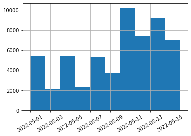

```python
df_edges['time'].hist(bins=10, xrot=30)
plt.savefig('../data/images/comments_repartition.pdf')
```

As it can be seen above, the comments is not exactly uniformly distributed along the days. However, it should not penalise the PageRank interpretation since we are to run the intersections between days.

```python
df_edges
```

|  | source | target | score | weight | time | sub |
| --- | --- | --- | --- | --- | --- | --- |
| 0 | amorydmart | Stevenlerma10 | 51 | 51.0 | 2022-05-15 | Dogecoin |
| 1 | azn1217 | Stevenlerma10 | 9 | 9.0 | 2022-05-15 | Dogecoin |
| 2 | azn1217 | amorydmart | 9 | 9.0 | 2022-05-15 | Dogecoin |
| 3 | DanAlucard | Stevenlerma10 | 9 | 9.0 | 2022-05-15 | Dogecoin |
| 4 | DanAlucard | amorydmart | 9 | 9.0 | 2022-05-15 | Dogecoin |
| ... | ... | ... | ... | ... | ... | ... |
| 104966 | explorer-9 | electricmaster23 | 5 | 5.0 | 2022-05-15 | Bitcoin |
| 104973 | geogrant1000 | Michellerose6834 | 3 | 3.0 | 2022-05-04 | CryptoCurrencies |
| 104974 | BasicallyTony | Michellerose6834 | 3 | 3.0 | 2022-05-04 | CryptoCurrencies |
| 104975 | BasicallyTony | geogrant1000 | 3 | 3.0 | 2022-05-04 | CryptoCurrencies |
| 104976 | phyLoGG | CRYPTOsauceNews | 7 | 7.0 | 2022-05-04 | CryptoCurrencies |

58150 rows × 6 columns

```python
days = df_edges.groupby('time').groups
days = np.array(list(days.keys()))[:-1]
graphs = [nx.from_pandas_edgelist(df_edges[df_edges['time']==day], create_using=nx.MultiDiGraph) for day in days]
ranks = [nx.pagerank(g) for g in graphs]
```

```python
first = graphs[0]
first_rank = ranks[0]
v = np.array(list(first_rank.values()))
first_node_sizes = (v - v.min()) / (v.max() - v.min())
```

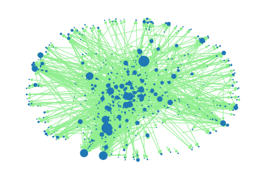

```python
nx.draw(first, pos=layout, node_size=first_node_sizes*300, edge_color='lightgreen')
```

[output not shown]

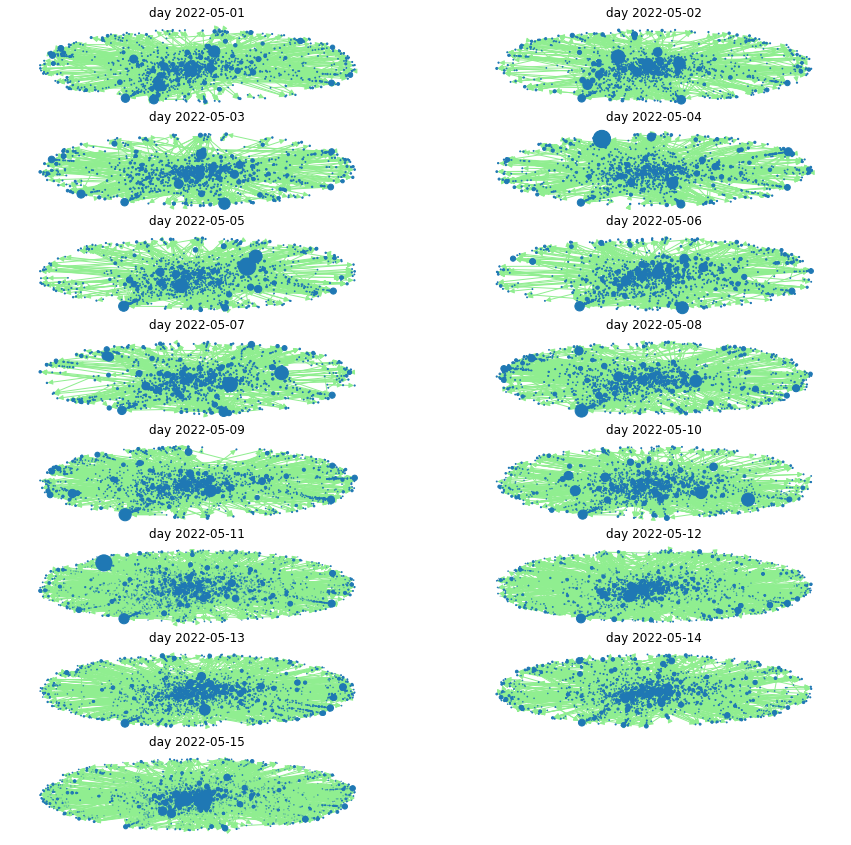

```python
rows, columns = len(graphs)//2+1, 2
fig, axs = plt.subplots(rows, columns, figsize=(15,15))
values = []
[[values.append(r[k]) for k in r] for r in ranks]
mn = min(values)
mx = max(values)
axs = axs.flatten()
[ax.axis('off') for ax in axs]
for i, graph in enumerate(graphs):
    r = np.array(list(ranks[i].values()))
    r = (r - mn) / (mx - mn)
    ax=axs[i]
    nx.draw(graph, pos=layout, node_size=r*300, edge_color='lightgreen', ax=ax)
    ax.set_title(f"day {days[i]}")
```

```python
fig.savefig('../data/images/nx_rep_days.pdf')
```

```python
error = 0
errors = []
sims = []
prev_rank = ranks[0]
for rank in ranks:
    r = set(rank)
    intersection = set(prev_rank).intersection(r)
    sim = len(intersection) / len(set(prev_rank).union(r))
    sims.append(sim)
    se = sum([(rank[k] - prev_rank[k])**2 for k in intersection])
    errors.append(se)
```

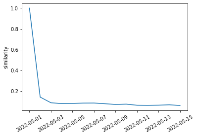

```python
ax=sns.lineplot(y=sims, x=days)
ax.set(ylabel="similarity")
_=plt.xticks(rotation=30)
plt.savefig('../data/images/sim_days.pdf',bbox_inches='tight')
```

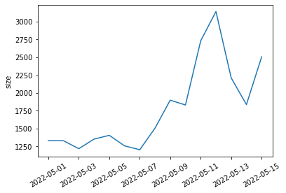

```python
ax=sns.lineplot(y=[len(r) for r in ranks], x=days)
ax.set(ylabel="size")
_=plt.xticks(rotation=30)
plt.savefig('../data/images/size_days.pdf',bbox_inches='tight')
```

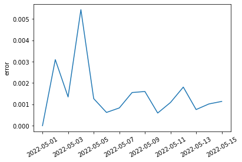

```python
ax=sns.lineplot(y=errors, x=days)
ax.set(ylabel="error")
_=plt.xticks(rotation=30)
plt.savefig('../data/images/error_days.pdf',bbox_inches='tight')
```

What can be observed above is that although the networks seems to change a lot during the days they remain quite steady in terms of pagerank. The discussion are therefore lasting. This is true that the graphs evolves quite rapidly over the days. The same users won't be active twice on the same posts. Now, there seems to be a high and lasting popularity of users' posts over the days.